# Homework 7

TJ Schaeffer

3/22/20

```r
# clean up workspace environment
rm(list = ls())

# all packages used for the assignment
library(MASS)
library(car)
library(nortest)
library(dplyr)
library(ggplot2)
library(readr)
# reading in data
bass <- read.csv("bass.csv")
```

1. Explanatory: Alkalinity Response: Mercury

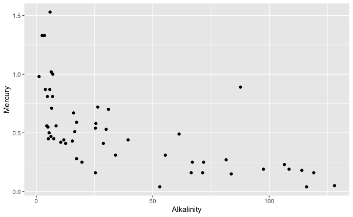

```r
bass %>%
  ggplot(aes(x = Alkalinity, y = Mercury)) +
  geom_point()
```

Based off the graph, I do not believe the data meets the linearity assumption, but it seems to be independent and normally distributed, and the residuals look to be homoskedastic.

```r
fit <- lm(Mercury~Alkalinity, data = bass)
summary(fit)
```

```
Call:
lm(formula = Mercury ~ Alkalinity, data = bass)

Residuals:
     Min       1Q   Median       3Q      Max
-0.42075 -0.19154 -0.03631  0.10914  0.84068

Coefficients:
              Estimate Std. Error t value Pr(>|t|)
(Intercept)  0.7221665  0.0514965  14.024  < 2e-16 ***
Alkalinity  -0.0055678  0.0009662  -5.762 4.82e-07 ***
---
Signif. codes:  0 ‘***’ 0.001 ‘**’ 0.01 ‘*’ 0.05 ‘.’ 0.1 ‘ ’ 1

Residual standard error: 0.2662 on 51 degrees of freedom
Multiple R-squared:  0.3943,    Adjusted R-squared:  0.3825
F-statistic:  33.2 on 1 and 51 DF,  p-value: 4.822e-07
```

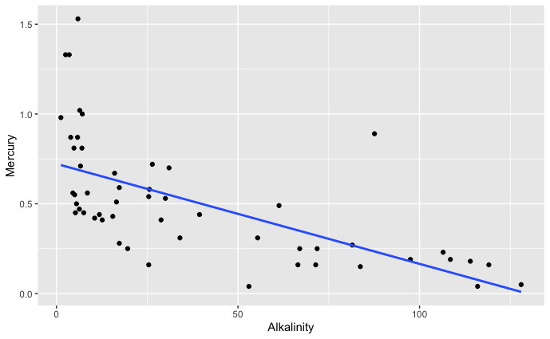

```r
bass %>%
  ggplot(aes(x = Alkalinity, y = Mercury)) +
  geom_point() +
  geom_smooth(method = 'lm', se = FALSE)
```

Based on the plot, it seems that a lake with 0 mg/l alkalinity contains .72 mg of Mercury and as the alkalinity of a lake increases by 1 mg/l, the amount of Mercury in that lake decreases by .005 mg.

```
"color" is not a graphical parameter
```

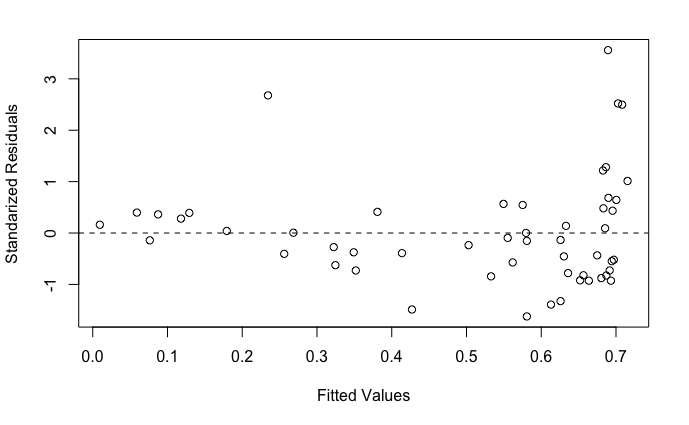

```r
# Std Res
bass.studentres <- studres(fit)
bass.fittedvalues <- fit$fitted

plot(bass.studentres~bass.fittedvalues, ylab = "Standarized Residuals", xlab = "Fitted Values")
abline(h = 0, color = "azure4", lty = 2)
```

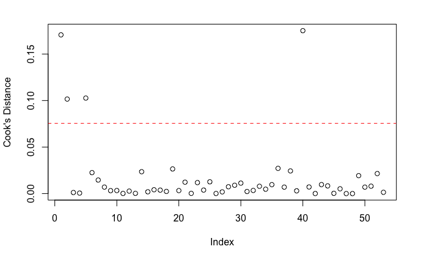

```r
#Cook's Distance
plot(cooks.distance(fit), ylab = "Cook's Distance")
abline(h = 4/53, col = "red", lty = 2)
```

Based off the two plots, it seems that there a few residuals that are different from the rest of the data, proving my assumption that there is outliers in the data.

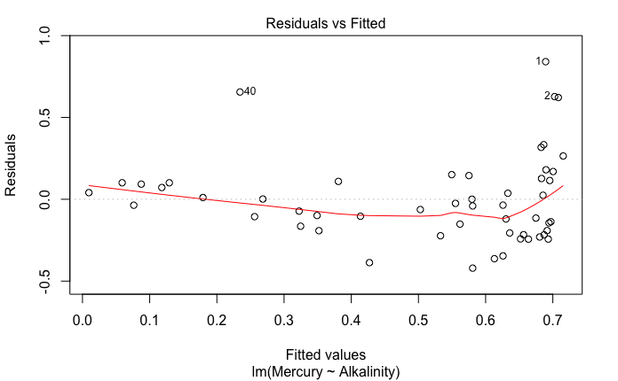

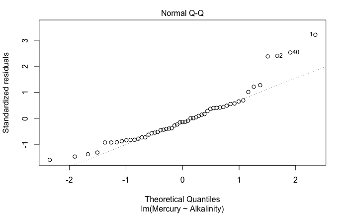

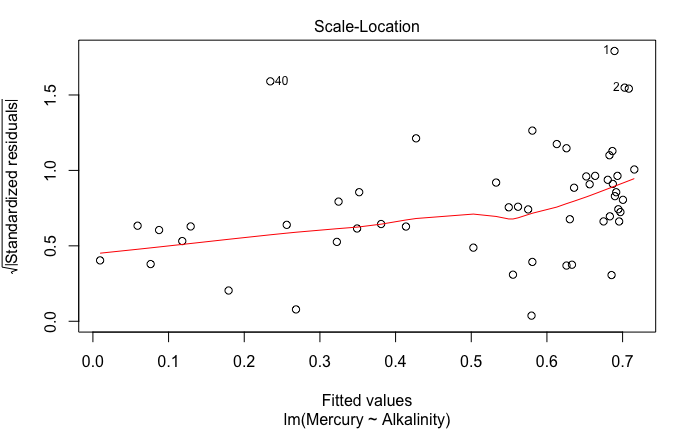

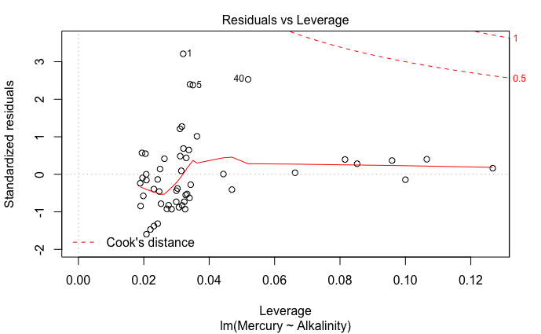

```r
plot(fit)
```

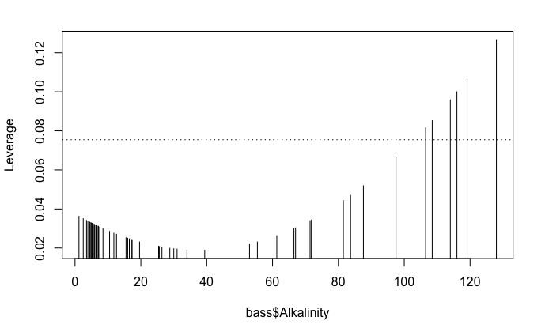

```r
plot(hatvalues(fit)~bass$Alkalinity, type = "h", ylab = "Leverage")
abline(h=((2*2)/nrow(bass)), lty = "dotted")
```

The name of the lake with highest residual mercury value: Alligator The name of the lake with highest leverage: Farm-14 The name of the lake with highest Cook’s distance: Puzzle

|  | StudRes | Hat | CookD |
| --- | --- | --- | --- |
| 1 | 3.5582169 | 0.03205029 | 0.170603320 |
| 15 | 0.1612766 | 0.12671220 | 0.001923747 |
| 35 | 0.3979077 | 0.10653745 | 0.009598155 |
| 40 | 2.6779962 | 0.05190044 | 0.175104117 |

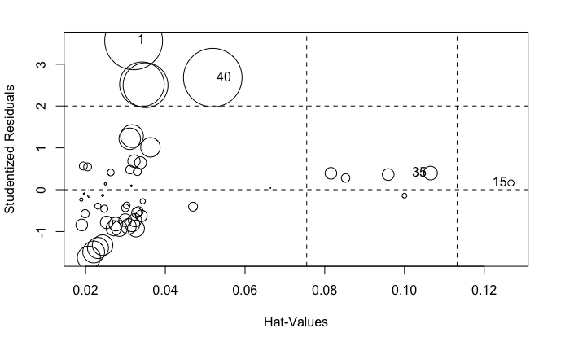

```r
influencePlot(fit)
```

I do not agree with this comment because based off the influence plot as well as the standard residual plot and the Cook’s Distance plot, it seems to me that there is a least 4 points that are influential.

8. Based off what we talked about in class, I would first start with transforming the explanatory variable and then if the adjusted R^2 value is too low, I would try transforming either just the response variable or possibly both to see what produces the highest adjusted R^2 value.

```r
# Log transformation
logfit <- lm(Mercury~log(Alkalinity), data = bass)
summary(logfit)
```

```
Call:
lm(formula = Mercury ~ log(Alkalinity), data = bass)

Residuals:
     Min       1Q   Median       3Q      Max
-0.33544 -0.13559 -0.00699  0.08440  0.76999

Coefficients:
                Estimate Std. Error t value Pr(>|t|)
(Intercept)      1.11730    0.08655  12.909  < 2e-16 ***
log(Alkalinity) -0.20129    0.02675  -7.525 8.09e-10 ***
---
Signif. codes:  0 ‘***’ 0.001 ‘**’ 0.01 ‘*’ 0.05 ‘.’ 0.1 ‘ ’ 1

Residual standard error: 0.2355 on 51 degrees of freedom
Multiple R-squared:  0.5261,    Adjusted R-squared:  0.5168
F-statistic: 56.62 on 1 and 51 DF,  p-value: 8.087e-10
```

```r
# Sqrt transformation
sqrtfit <- lm(Mercury~sqrt(Alkalinity), data = bass)
summary(sqrtfit)
```

```
Call:
lm(formula = Mercury ~ sqrt(Alkalinity), data = bass)

Residuals:
     Min       1Q   Median       3Q      Max
-0.37523 -0.18882 -0.01197  0.09331  0.79688

Coefficients:
                 Estimate Std. Error t value Pr(>|t|)
(Intercept)       0.91722    0.06970  13.159  < 2e-16 ***
sqrt(Alkalinity) -0.07580    0.01138  -6.662 1.86e-08 ***
---
Signif. codes:  0 ‘***’ 0.001 ‘**’ 0.01 ‘*’ 0.05 ‘.’ 0.1 ‘ ’ 1

Residual standard error: 0.2501 on 51 degrees of freedom
Multiple R-squared:  0.4653,    Adjusted R-squared:  0.4548
F-statistic: 44.38 on 1 and 51 DF,  p-value: 1.864e-08
```

Pick: Log

```r
AICc(logfit, sqrtfit)
```

|  | df | AICc |
| --- | --- | --- |
| logfit | 3 | 1.555881 |
| sqrtfit | 3 | 7.958880 |

Logfit seems to have a higher adjust R^2 value and has a lower AIC value.

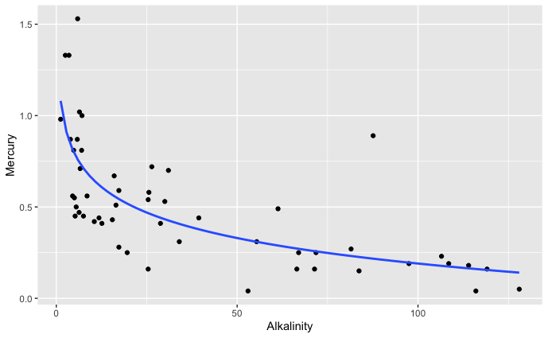

```r
# Log transformation plot
bass %>%
  ggplot(aes(x = Alkalinity, y = Mercury)) +
  geom_point() +
  geom_smooth(method = 'lm', formula = y~log(x), se = FALSE)
```

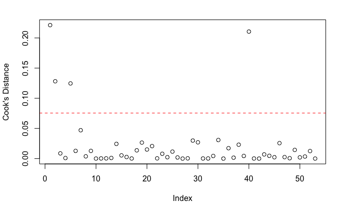

```r
#Cook's Distance
plot(cooks.distance(logfit), ylab = "Cook's Distance")
abline(h = 4/53, col = "red", lty = 2)
```

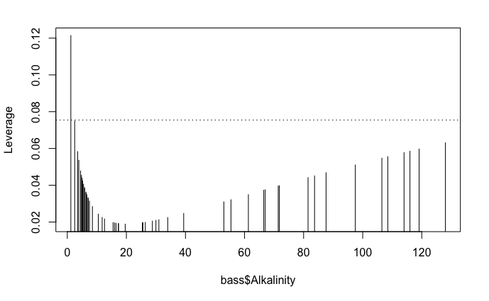

```r
# High Leverage
plot(hatvalues(logfit)~bass$Alkalinity, type = "h", ylab = "Leverage")
abline(h=((2*2)/nrow(bass)), lty = "dotted")
```

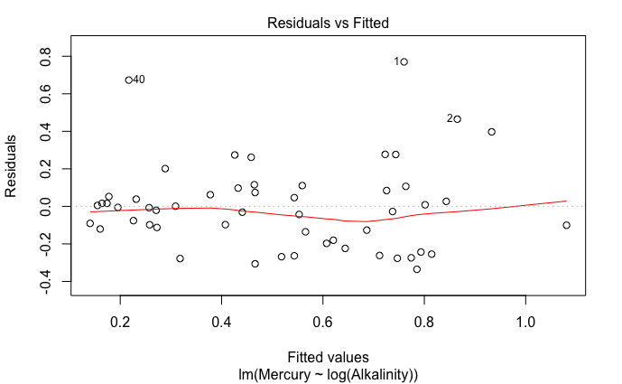

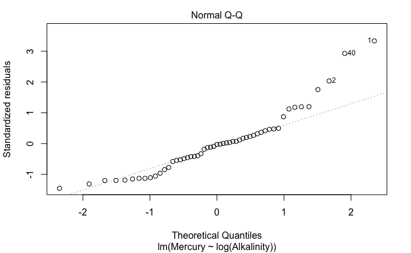

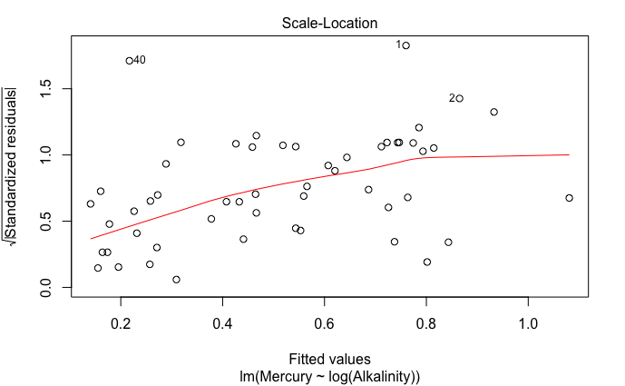

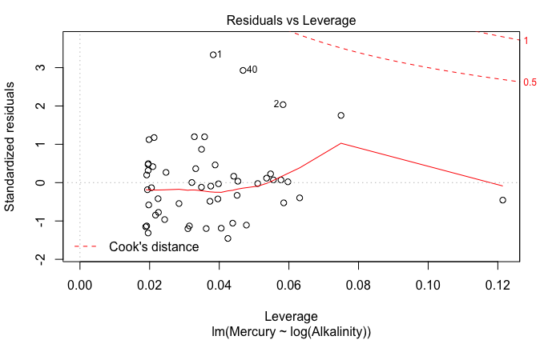

```r
# Normal Residual
plot(logfit)
```

```
"color" is not a graphical parameter
```

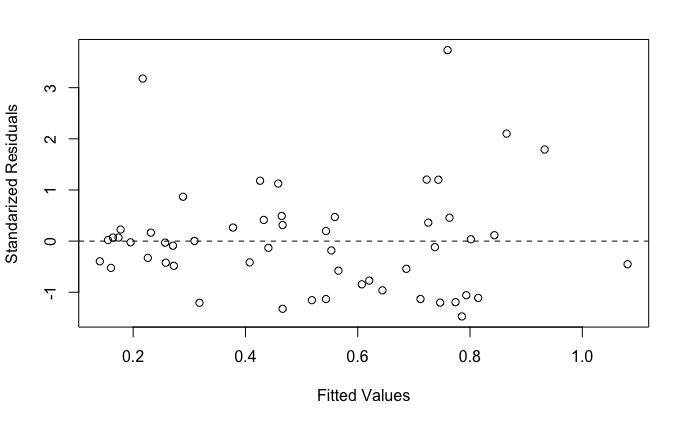

```r
# Std Red
bass.studentres2 <- studres(logfit)
bass.fittedvalues2 <- logfit$fitted
plot(bass.studentres2~bass.fittedvalues2, ylab = "Standarized Residuals", xlab = "Fitted Values")
abline(h = 0, color = "azure4", lty = 2)
```

```r
newlake <- data.frame(Alkalinity = 40)
predict(logfit, newdata = newlake, interval = 'prediction', level = 0.99)
```

```
        fit        lwr      upr
1 0.3747508 -0.2630697 1.012571
```

No because the 99% prediction interval goes above 1mg of Mercury, meaning that there is a chance that a fish can contain more than 1 mg of Mercury.

```r
newlake2 <- data.frame(Alkalinity = 20)
predict(logfit, newdata = newlake2, interval = 'prediction', level = 0.95)
```

```
        fit        lwr      upr
1 0.5142775 0.03715097 0.991404
```